# Test a Perceptual Phenomenon

### Question 1: What is our independent variable? What is our dependent variable?

Independant variable = Word condition

Dependant variable = Response time in seconds

### Question 2: What is an appropriate set of hypotheses for this task? What kind of statistical test do you expect to perform? Justify your choices.

The null hypothesis should be that the mean time for colour recognition for congruent words is equal to or greater than the mean time for incongruent words, therefore implying a one-tailed test. The alternative hypothesis should be that the congruent words mean is less than the incongruent words mean.

H0: μC ≥ μI

HA: μC < μI

where μ is a population mean, the subscript "C" represents the congruent words condition, and the subscript "I" represents the incongruent words condition.

A one-tailed, dependent samples t-test comparing the difference in means (the time to name the ink colors for congruent words and incongruent words) should be performed. With this test, we seek to determine whether there is enough evidence in the provided sample of data to infer that the congruent words mean colour recognition time is less than the incongruent words mean colour recognition time for the entire population and not just the sample data.

A t-test is appropriate because the population variance is unknown and the sample size is less than 30. When the sample size is less than 30, the sample data no longer approximate a normal distribution, which makes the use of a Z-value inappropriate.1 The following assumptions are required for t-tests for dependent means:2

Interval or ratio scale of measurement (approximately interval) Random sampling from a defined population Samples or sets of data used to produce the difference scores are linked in the population through repeated measurement, natural association, or matching Scores are normally distributed in the population; difference scores are normally distributed A one-tailed test is appropriate under the assumption that incongruent word conditions will not improve recognition times, which is intuitive. The one-tailed test allows for a more scrutinous examination of the negative impact of incongruent word conditions on recognition times.

The t-test should be of the dependent samples variety because the same subject is exposed to two conditions and tested for each, which are the defining criteria for "within-subjects" or "repeated-measures" statistical tests

### Question 3: Report some descriptive statistics regarding this dataset. Include at least one measure of central tendency and at least one measure of variability.

```python
import pandas as pd


data_frame = pd.read_csv('C:/Users/rahul/Desktop/udacity_DA_ND/Test_A_Perceptual_Phenomenon/stroopdata.csv')

data_frame.describe()
```

|  | Congruent | Incongruent |
| --- | --- | --- |
| count | 24.000000 | 24.000000 |
| mean | 14.051125 | 22.015917 |
| std | 3.559358 | 4.797057 |
| min | 8.630000 | 15.687000 |
| 25% | 11.895250 | 18.716750 |
| 50% | 14.356500 | 21.017500 |
| 75% | 16.200750 | 24.051500 |
| max | 22.328000 | 35.255000 |

### Question 4: Provide one or two visualizations that show the distribution of the sample data. Write one or two sentences noting what you observe about the plot or plots.

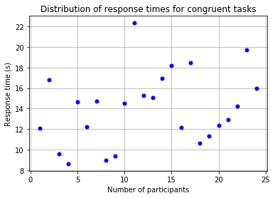

```python
import matplotlib.pyplot as plt
%pylab inline


data_frame['num_participants'] = data_frame.index + 1
x = data_frame['num_participants']
congruent_y = data_frame['Congruent']
incongruent_y = data_frame['Incongruent']

plt.plot(x, congruent_y, 'o', markersize=5, color='b')
plt.title('Distribution of response times for congruent tasks')
plt.xlabel('Number of participants')
plt.ylabel('Response time (s)')
plt.grid()
```

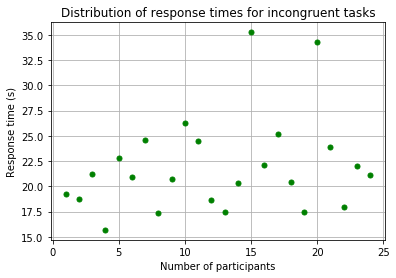

```python
plt.plot(x, incongruent_y, 'o', markersize=5, color='g')
plt.title('Distribution of response times for incongruent tasks')
plt.xlabel('Number of participants')
plt.ylabel('Response time (s)')
plt.grid()
```

The above graphs illustrates the response time distributions for the congruent and incongruent tasks, respectively. It can be easily observed that on average the incongruent tasks (22s) takes longer than congruent tasks (14s).

### Question 5: Now, perform the statistical test and report your results. What is your confidence level and your critical statistic value? Do you reject the null hypothesis or fail to reject it? Come to a conclusion in terms of the experiment task. Did the results match up with your expectations?

```
α = .01
df = 23
tcrit = -2.50
```

```python
from scipy import stats

stats.ttest_rel(data_frame['Congruent'], data_frame['Incongruent'])
```

```
Ttest_relResult(statistic=-8.020706944109957, pvalue=4.1030005857111781e-08)
```

At the 99% confidence level (α = .01) and 23 degrees of freedom, the critical statistic value for a one-tailed test in the negative direction is -2.5. The calculated t-statistic for the difference in colour recognition time means of the congruent and incongruent word data is -8.02. Since the t-statistic is in the critical region, the null hypothesis is rejected. With the data presented, it is very unlikely that the 7.96 second difference in mean time for colour recognition for the congruent data vs. the incongruent data is obtained if the two means are actually the same (or if μC > μI). By conventional criteria, this difference is considered to be extremely statistically significant.

There is sufficient evidence at the α = .01 level of significance to support the claim that it takes less time to recognize the colour of words with the congruent condition compared to words with the incongruent condition.

### Question 6: Optional: What do you think is responsible for the effects observed? Can you think of an alternative or similar task that would result in a similar effect? Some research about the problem will be helpful for thinking about these two questions!

There are several theories used to explain the Stroop effect and are commonly known as ‘race models’. This is based on the underlying notion that both relevant and irrelevant information are processed in parallel, but "race" to enter the single central processor during response selection.

There is an other variation to classic stroop effect called 'warped words Stroop effect'. It produces the same findings similar to the original Stroop effect. Much like the Stroop task, the printed word's color is different from the ink color of the word; however, the words are printed in such a way that it is more difficult to read (typically curved-shaped).[35] The idea here is the way the words are printed slows down both the brain's reaction and processing time, making it harder to complete the task.

### References

- [Stroop effect](https://en.wikipedia.org/wiki/Stroop_effect)
- [Wraped words Stroop effect](https://prezi.com/bukyb3sup1mb/warped-words-and-the-stroop-test/)
- [SciPy documentation](http://docs.scipy.org/doc/scipy/reference/generated/scipy.stats.ttest_rel.html)